## Association Mining

**Objectives**:

The objective of this document is to give a brief introduction to association mining. This document assumes the users have no prior knowledge of R. After completing this tutorial, you will be able to:

- Mine associated sets
- Find closed and maximal item sets
- Use different interestingness measures
- Visualize associations

Let’s load our main data to use:

```r
load(url("http://www.rdatamining.com/data/titanic.raw.rdata?attredirects=0&d= 1"))
```

Install and load packages:

```r
#install.packages("arules")
require(arules)
```

### Maximal and Closed Itemsets

Mine the closed and maximal itemsets:

```r
closed.itemset <- apriori(titanic.raw, parameter = list(target="closed frequent itemsets"))
```

```
Apriori

Parameter specification:
 confidence minval smax arem  aval originalSupport maxtime support minlen maxlen                   target   ext
         NA    0.1    1 none FALSE            TRUE       5     0.1      1     10 closed frequent itemsets FALSE

Algorithmic control:
 filter tree heap memopt load sort verbose
    0.1 TRUE TRUE  FALSE TRUE    2    TRUE

Absolute minimum support count: 220

set item appearances ...[0 item(s)] done [0.01s].
set transactions ...[10 item(s), 2201 transaction(s)] done [0.01s].
sorting and recoding items ... [9 item(s)] done [0.00s].
creating transaction tree ... done [0.00s].
checking subsets of size 1 2 3 4 done [0.08s].
filtering closed item sets ... done [0.00s].
writing ... [31 set(s)] done [0.01s].
creating S4 object  ... done [0.01s].
```

```r
max.itemset <- apriori(titanic.raw, parameter = list(target="maximally frequent itemsets"))
```

```
Apriori

Parameter specification:
 confidence minval smax arem  aval originalSupport maxtime support minlen maxlen                      target   ext
         NA    0.1    1 none FALSE            TRUE       5     0.1      1     10 maximally frequent itemsets FALSE

Algorithmic control:
 filter tree heap memopt load sort verbose
    0.1 TRUE TRUE  FALSE TRUE    2    TRUE

Absolute minimum support count: 220

set item appearances ...[0 item(s)] done [0.01s].
set transactions ...[10 item(s), 2201 transaction(s)] done [0.01s].
sorting and recoding items ... [9 item(s)] done [0.00s].
creating transaction tree ... done [0.00s].
checking subsets of size 1 2 3 4 done [0.04s].
filtering maximal item sets ... done [0.00s].
writing ... [6 set(s)] done [0.01s].
creating S4 object  ... done [0.02s].
```

### Initial Mining

Mine initial association rules with default settings (i.e `minsup = 0.1`, `mincon = 0.8`, `maxlength = 10`).

```r
rules <- apriori(titanic.raw)
```

```
Apriori

Parameter specification:
 confidence minval smax arem  aval originalSupport maxtime support minlen maxlen target   ext
        0.8    0.1    1 none FALSE            TRUE       5     0.1      1     10  rules FALSE

Algorithmic control:
 filter tree heap memopt load sort verbose
    0.1 TRUE TRUE  FALSE TRUE    2    TRUE

Absolute minimum support count: 220

set item appearances ...[0 item(s)] done [0.01s].
set transactions ...[10 item(s), 2201 transaction(s)] done [0.01s].
sorting and recoding items ... [9 item(s)] done [0.00s].
creating transaction tree ... done [0.00s].
checking subsets of size 1 2 3 4 done [0.01s].
writing ... [27 rule(s)] done [0.01s].
creating S4 object  ... done [0.01s].
```

This creates a total of 27 rules, which is not a lot. However when you have a larger dataset, you are likely to get a much bigger rule set.

Let’s inspect the rules:

```r
inspect(rules)
```

```
     lhs                                   rhs           support   confidence lift      count
[1]  {}                                 => {Age=Adult}   0.9504771 0.9504771  1.0000000 2092
[2]  {Class=2nd}                        => {Age=Adult}   0.1185825 0.9157895  0.9635051  261
[3]  {Class=1st}                        => {Age=Adult}   0.1449341 0.9815385  1.0326798  319
[4]  {Sex=Female}                       => {Age=Adult}   0.1930940 0.9042553  0.9513700  425
[5]  {Class=3rd}                        => {Age=Adult}   0.2848705 0.8881020  0.9343750  627
[6]  {Survived=Yes}                     => {Age=Adult}   0.2971377 0.9198312  0.9677574  654
[7]  {Class=Crew}                       => {Sex=Male}    0.3916402 0.9740113  1.2384742  862
[8]  {Class=Crew}                       => {Age=Adult}   0.4020900 1.0000000  1.0521033  885
[9]  {Survived=No}                      => {Sex=Male}    0.6197183 0.9154362  1.1639949 1364
[10] {Survived=No}                      => {Age=Adult}   0.6533394 0.9651007  1.0153856 1438
[11] {Sex=Male}                         => {Age=Adult}   0.7573830 0.9630272  1.0132040 1667
[12] {Sex=Female,Survived=Yes}          => {Age=Adult}   0.1435711 0.9186047  0.9664669  316
[13] {Class=3rd,Sex=Male}               => {Survived=No} 0.1917310 0.8274510  1.2222950  422
[14] {Class=3rd,Survived=No}            => {Age=Adult}   0.2162653 0.9015152  0.9484870  476
[15] {Class=3rd,Sex=Male}               => {Age=Adult}   0.2099046 0.9058824  0.9530818  462
[16] {Sex=Male,Survived=Yes}            => {Age=Adult}   0.1535666 0.9209809  0.9689670  338
[17] {Class=Crew,Survived=No}           => {Sex=Male}    0.3044071 0.9955423  1.2658514  670
[18] {Class=Crew,Survived=No}           => {Age=Adult}   0.3057701 1.0000000  1.0521033  673
[19] {Class=Crew,Sex=Male}              => {Age=Adult}   0.3916402 1.0000000  1.0521033  862
[20] {Class=Crew,Age=Adult}             => {Sex=Male}    0.3916402 0.9740113  1.2384742  862
[21] {Sex=Male,Survived=No}             => {Age=Adult}   0.6038164 0.9743402  1.0251065 1329
[22] {Age=Adult,Survived=No}            => {Sex=Male}    0.6038164 0.9242003  1.1751385 1329
[23] {Class=3rd,Sex=Male,Survived=No}   => {Age=Adult}   0.1758292 0.9170616  0.9648435  387
[24] {Class=3rd,Age=Adult,Survived=No}  => {Sex=Male}    0.1758292 0.8130252  1.0337773  387
[25] {Class=3rd,Sex=Male,Age=Adult}     => {Survived=No} 0.1758292 0.8376623  1.2373791  387
[26] {Class=Crew,Sex=Male,Survived=No}  => {Age=Adult}   0.3044071 1.0000000  1.0521033  670
[27] {Class=Crew,Age=Adult,Survived=No} => {Sex=Male}    0.3044071 0.9955423  1.2658514  670
```

Even with 27 rules, it is very difficult to interpret their meaning. We might need to be more specific about what we are looking for. Assume we are interested in the rules that point to the survival status of the individuals, this means we want the Survived variable to be on the right hand side of the association rule.

### Refine the Results

```r
rules.survived <- apriori(titanic.raw,
                 parameter = list(minlen=2, supp=0.005, conf=0.8),
                 appearance = list(rhs=c("Survived=No", "Survived=Yes"),
                                   default="lhs"),
                 control = list(verbose=F))
rules.survived<-sort(rules.survived,by="lift")
quality(rules.survived)<-round(quality(rules.survived),digits=3) #Round the values of interest measure to three digits after decimal point
```

Before we intrepret the rules, let’s go over the code. The setting `parameter = list(...)` allows you to set the parameters such as minimum support/confidence. The setting `appearance = list(...)` allows you to control which rules appear on the right and left hand sides of the rule set.

When we inspect the rules below, we can see that children and female are more likely to survive than men. However, there is some redundancy in the rules. For example; rule 2 provides no extra knowledge in addition to rule 1, since rules 1 tells us that all 2nd-class children survived. Generally speaking, when a rule (such as rule 2) is a super rule of another rule (such as rule 1) and the former has the same or a lower lift, the former rule (rule 2) is considered to be redundant.

```r
inspect(rules.survived)
```

```
     lhs                                  rhs            support confidence lift  count
[1]  {Class=2nd,Age=Child}             => {Survived=Yes} 0.011   1.000      3.096  24
[2]  {Class=2nd,Sex=Female,Age=Child}  => {Survived=Yes} 0.006   1.000      3.096  13
[3]  {Class=1st,Sex=Female}            => {Survived=Yes} 0.064   0.972      3.010 141
[4]  {Class=1st,Sex=Female,Age=Adult}  => {Survived=Yes} 0.064   0.972      3.010 140
[5]  {Class=2nd,Sex=Female}            => {Survived=Yes} 0.042   0.877      2.716  93
[6]  {Class=Crew,Sex=Female}           => {Survived=Yes} 0.009   0.870      2.692  20
[7]  {Class=Crew,Sex=Female,Age=Adult} => {Survived=Yes} 0.009   0.870      2.692  20
[8]  {Class=2nd,Sex=Female,Age=Adult}  => {Survived=Yes} 0.036   0.860      2.663  80
[9]  {Class=2nd,Sex=Male,Age=Adult}    => {Survived=No}  0.070   0.917      1.354 154
[10] {Class=2nd,Sex=Male}              => {Survived=No}  0.070   0.860      1.271 154
[11] {Class=3rd,Sex=Male,Age=Adult}    => {Survived=No}  0.176   0.838      1.237 387
[12] {Class=3rd,Sex=Male}              => {Survived=No}  0.192   0.827      1.222 422
```

### Pruning

First we find rules that are subset of the rules:

```r
subset.matrix <- is.subset(rules.survived@lhs, rules.survived@lhs,sparse=FALSE)
subset.matrix[lower.tri(subset.matrix, diag=T)] <- NA #Lower triangle and upper triangle are the same so in order to use only one of those, we make lower triangle NA
```

Find the redundant rules:

```r
redundant <- (colSums(subset.matrix, na.rm=T))==1  #We sum the columns of subset.matrix (matrix of 1s and 0s) to see how many supersets a column has. na.rm=T ignores the NA values
which(redundant) #returns redundant sets
```

```
 {Class=2nd,Sex=Female,Age=Child}  {Class=1st,Sex=Female,Age=Adult} {Class=Crew,Sex=Female,Age=Adult}
                                2                                 4                                 7
 {Class=2nd,Sex=Female,Age=Adult}
                                8
```

Obtain non-redundant rule sets:

```r
rules.pruned <- rules.survived[!redundant]
inspect(rules.pruned)
```

```
    lhs                               rhs            support confidence lift  count
[1] {Class=2nd,Age=Child}          => {Survived=Yes} 0.011   1.000      3.096  24
[2] {Class=1st,Sex=Female}         => {Survived=Yes} 0.064   0.972      3.010 141
[3] {Class=2nd,Sex=Female}         => {Survived=Yes} 0.042   0.877      2.716  93
[4] {Class=Crew,Sex=Female}        => {Survived=Yes} 0.009   0.870      2.692  20
[5] {Class=2nd,Sex=Male,Age=Adult} => {Survived=No}  0.070   0.917      1.354 154
[6] {Class=2nd,Sex=Male}           => {Survived=No}  0.070   0.860      1.271 154
[7] {Class=3rd,Sex=Male,Age=Adult} => {Survived=No}  0.176   0.838      1.237 387
[8] {Class=3rd,Sex=Male}           => {Survived=No}  0.192   0.827      1.222 422
```

Now the relationships are much clearer!

### Different Interestingness Measures

Suppose we want to see `gini`, `leverage` and `oddsRatio` interest measures. We can mine those using the following code:

```r
measure.names <- c("gini", "leverage", "oddsRatio") #Make a name vector of in terestingness measures that we want
measure.values <- interestMeasure(rules.pruned, measure.names, transactions = titanic.raw)
measure.values
```

| gini | leverage | oddsRatio |
| --- | --- | --- |
| 0.010195465 | 0.007447028 | NA |
| 0.059390335 | 0.042737542 | 90.529504 |
| 0.030886382 | 0.026536082 | 17.037188 |
| 0.006251129 | 0.005656761 | 14.388224 |
| 0.009500632 | 0.018301329 | 5.756708 |
| 0.005958615 | 0.014925256 | 3.159078 |
| 0.013706608 | 0.033720291 | 2.976442 |
| 0.013649981 | 0.034880524 | 2.791492 |

This command gives us the new interest measures in a data frame for each of the rules we provided. For other measures, see help documentation for `interestMeasure` function.

## Visualization

After obtaining rules, we can visualize them for better exploration. We can use scatter plots, balloon plots and parallel coordinates plots. The details of those plots will be explained in class.

Install and load the required package:

```r
#install.packages("arulesViz")
require(arulesViz)
```

### Scatterplot

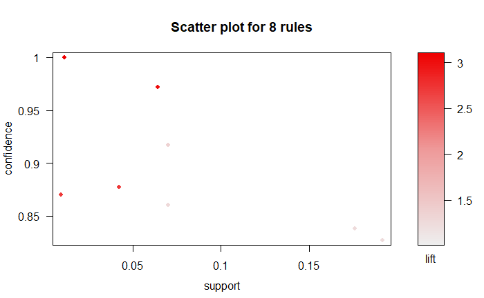

```r
plot(rules.pruned)
```

The scatter plot gives us information about how support-confidence-lift measures are distributed along retained rules. However, it is not very helpful to actually see which rules have which values.

To see the relationship between rules we can use either a balloon plot or parallel coordinates graph.

[output not shown]

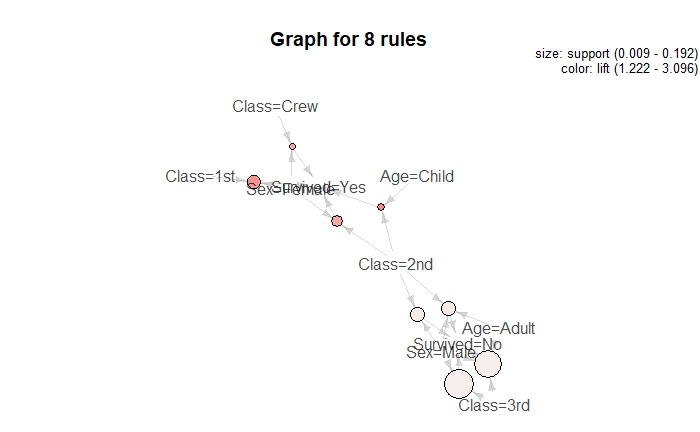

```r
plot(rules.pruned, method="graph", control=list(type="items"))
```

The balloon plot gives us information about the rules, support and lift measures. However it doesn’t give us any information about confidence levels.

### Parallel Coordinates Plot

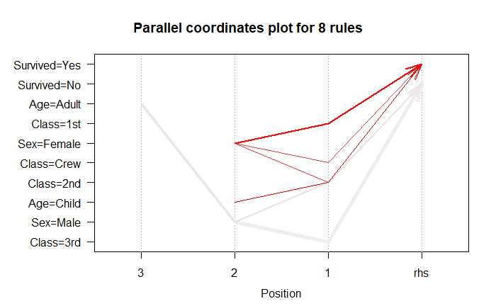

```r
plot(rules.pruned, method="paracoord", control=list(reorder=TRUE))
```

Parallel coordinates plots give us an excellent picture of rules.

## Useful Links

- Association Mining datasets: http://fimi.ua.ac.be/data/
  - This webpage holds datasets for association mining
- Information about sequential association mining techniques: http://research.microsoft.com/pubs/217091/gupta11a_apdsdm.pdf
  - This document holds information regarding a somewhat more advanced topic: sequential mining